# R Notebook

# Finding the rows of outliers in age column

```r
outliers = boxplot.stats(data$age)$out
outliers_ind = which(data$age %in% c(outliers))
data[outliers_ind,]
```

|  | first_name | last_name | gender | age | education | marital_status | occupation_group | credit_score | address | city | state | home_build_year |
| --- | --- | --- | --- | --- | --- | --- | --- | --- | --- | --- | --- | --- |
| 430 | Daniel | Moran | Male | 113 | Some College | Married | Management | 639 | 801 Delgado Circle Suite 085 | Navarre | FL | 2011 |
| 583 | Linda | Anthony | Female | 112 | HS Diploma | Married | Retired | 731 | 51824 Perry Lodge Apt. 949 | Milton | FL | 1972 |
| 1840 | Wallace | Garner | Male | 134 | HS Diploma | Married | Blue Collar | 504 | 3992 Kim Well Apt. 454 | Molino | FL | 2016 |
| 2917 | William | Wilson | Male | 115 | Bach Degree | Married | Professional | 720 | 4844 Cory Parkways | Miramar beach | FL | 2013 |
| 3855 | Lorie | Vincent | Female | 123 | Some College | Married | Professional | 834 | 204 Cynthia Circles Suite 482 | Pensacola | FL | 2014 |
| 5205 | Evelyn | Rodriguez | Female | 105 | Some College | Married | Professional | 513 | 796 Wagner Land | Fort walton beach | FL | 1973 |
| 5873 | Simon | Livingston | Male | 119 | Grad Degree | Single | Blue Collar | 712 | 1804 Harris Club | Crestview | FL | 2002 |
| 6868 | Joshua | Kim | Male | 107 | Grad Degree | Married | Other | 717 | 9648 Angela Common | Pensacola | FL | 1976 |
| 7106 | James | Johns | Male | 110 | Some College | Married | Management | 441 | 24005 Tapia Place Suite 965 | Pensacola | FL | 2014 |

#Removing outliers with Inter Quartile Range Method

```r
P1<- quantile(data$age, 0.25)
P2 <- quantile(data$age, 0.75)
IQR_age <- P2 - P1
```

#getting lower and upper limits for outliers

```r
lower_limit <- P1 - 1.5 * IQR_age
upper_limit <- P2 + 1.5 * IQR_age
```

#Removing outliers using filter

```r
data <- data %>% filter(age >= lower_limit & age <= upper_limit)
```

#Using boxplot

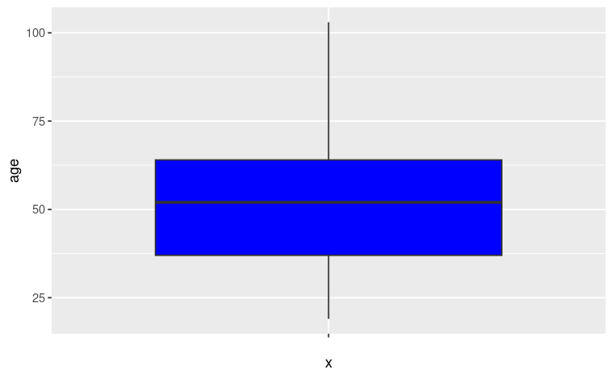

```r
ggplot(data)+aes(x="",  y=age)+geom_boxplot(fill="blue")
```

Hence, there are no outliers in this age column. #Using the filter function:

1.The filter function enables users to organize data according to the requirement. 2.Here the filter function allows us to analyse the persons who have low/average/excellent credit score. Data can be organized according to specific age groups, gender and occupation groups. 3.Also, the filter function can be used with “or” , “and” operator to gain deeper insights into the data.

#Generation of new variables

```r
data <- data %>%
  mutate(age_group = cut(age, breaks = c(0, 20, 30, 40, 50, 60, Inf),
labels = c("0-20", "21-30", "31-40", "41-50", "51-60", "61+")))
```

```r
head(data,n=10)
```

|  | first_name | last_name | gender | age | education | marital_status | occupation_group | credit_score | address | city | state | home_build_year | age_group |
| --- | --- | --- | --- | --- | --- | --- | --- | --- | --- | --- | --- | --- | --- |
| 1 | Brian | Thomas | Male | 39 | Some College | Married | Management | 502 | 527 Ronald Loop | Pensacola | FL | 1986 | 31-40 |
| 2 | Malcolm | Ryan | Male | 76 | HS Diploma | Married | Retired | 379 | 91598 Victoria Inlet Suite 556 | Panama city | FL | 1971 | 61+ |
| 3 | Matthew | Brooks | Male | 47 | Grad Degree | Married | Professional | 458 | 86685 Lynn Gardens | Gulf breeze | FL | 2007 | 41-50 |
| 4 | Tommy | Harris | Male | 69 | Grad Degree | Married | Professional | 621 | 37686 Thomas Bypass | Fort walton beach | FL | 1999 | 61+ |
| 5 | Ronald | Hurst | Male | 52 | Some College | Married | Blue Collar | 349 | 2138 Whitehead Valleys Apt. 889 | Pensacola | FL | 1982 | 51-60 |
| 6 | Kylee | Sullivan | Female | 23 | Some College | Married | Other | 566 | 51292 Wolfe Light Suite 812 | Panama city | FL | 2015 | 21-30 |
| 7 | Jerry | Davis | Male | 65 | Some College | Married | Retired | 390 | 34035 Scott Causeway | Lynn haven | FL | 1991 | 61+ |
| 8 | John | Odonnell | Male | 58 | HS Diploma | Married | Blue Collar | 827 | 05595 Ray Crescent | Fort walton beach | FL | 1989 | 51-60 |
| 9 | Jimmy | Avery | Male | 75 | HS Diploma | Married | Retired | 540 | 0704 Brown Bridge | Panama city | FL | 1974 | 61+ |
| 10 | Janie | Hernandez | Female | 64 | Grad Degree | Married | Office Administration | 560 | 337 Stephen Ranch Apt. 643 | Destin | FL | 2022 | 61+ |

```r
view(data)
```

```r
data %>%
  mutate(credit_score_rating = cut(credit_score, breaks = c(300, 550, 650, 750, 800, 850), labels = c("poor", "fair", "good", "very good", "excellent")))
```

| first_name | last_name | gender | age | education | marital_status | occupation_group | credit_score | address | city | state | home_build_year | age_group | credit_score_rating |
| --- | --- | --- | --- | --- | --- | --- | --- | --- | --- | --- | --- | --- | --- |
| Brian | Thomas | Male | 39 | Some College | Married | Management | 502 | 527 Ronald Loop | Pensacola | FL | 1986 | 31-40 | poor |
| Malcolm | Ryan | Male | 76 | HS Diploma | Married | Retired | 379 | 91598 Victoria Inlet Suite 556 | Panama city | FL | 1971 | 61+ | poor |
| Matthew | Brooks | Male | 47 | Grad Degree | Married | Professional | 458 | 86685 Lynn Gardens | Gulf breeze | FL | 2007 | 41-50 | poor |
| Tommy | Harris | Male | 69 | Grad Degree | Married | Professional | 621 | 37686 Thomas Bypass | Fort walton beach | FL | 1999 | 61+ | fair |
| Ronald | Hurst | Male | 52 | Some College | Married | Blue Collar | 349 | 2138 Whitehead Valleys Apt. 889 | Pensacola | FL | 1982 | 51-60 | poor |
| Kylee | Sullivan | Female | 23 | Some College | Married | Other | 566 | 51292 Wolfe Light Suite 812 | Panama city | FL | 2015 | 21-30 | fair |
| Jerry | Davis | Male | 65 | Some College | Married | Retired | 390 | 34035 Scott Causeway | Lynn haven | FL | 1991 | 61+ | poor |
| John | Odonnell | Male | 58 | HS Diploma | Married | Blue Collar | 827 | 05595 Ray Crescent | Fort walton beach | FL | 1989 | 51-60 | excellent |
| Jimmy | Avery | Male | 75 | HS Diploma | Married | Retired | 540 | 0704 Brown Bridge | Panama city | FL | 1974 | 61+ | poor |
| Janie | Hernandez | Female | 64 | Grad Degree | Married | Office Administration | 560 | 337 Stephen Ranch Apt. 643 | Destin | FL | 2022 | 61+ | fair |

[output cut: 990 more lines]

```r
head(data,n=10)
```

|  | first_name | last_name | gender | age | education | marital_status | occupation_group | credit_score | address | city | state | home_build_year | age_group |
| --- | --- | --- | --- | --- | --- | --- | --- | --- | --- | --- | --- | --- | --- |
| 1 | Brian | Thomas | Male | 39 | Some College | Married | Management | 502 | 527 Ronald Loop | Pensacola | FL | 1986 | 31-40 |
| 2 | Malcolm | Ryan | Male | 76 | HS Diploma | Married | Retired | 379 | 91598 Victoria Inlet Suite 556 | Panama city | FL | 1971 | 61+ |
| 3 | Matthew | Brooks | Male | 47 | Grad Degree | Married | Professional | 458 | 86685 Lynn Gardens | Gulf breeze | FL | 2007 | 41-50 |
| 4 | Tommy | Harris | Male | 69 | Grad Degree | Married | Professional | 621 | 37686 Thomas Bypass | Fort walton beach | FL | 1999 | 61+ |
| 5 | Ronald | Hurst | Male | 52 | Some College | Married | Blue Collar | 349 | 2138 Whitehead Valleys Apt. 889 | Pensacola | FL | 1982 | 51-60 |
| 6 | Kylee | Sullivan | Female | 23 | Some College | Married | Other | 566 | 51292 Wolfe Light Suite 812 | Panama city | FL | 2015 | 21-30 |
| 7 | Jerry | Davis | Male | 65 | Some College | Married | Retired | 390 | 34035 Scott Causeway | Lynn haven | FL | 1991 | 61+ |
| 8 | John | Odonnell | Male | 58 | HS Diploma | Married | Blue Collar | 827 | 05595 Ray Crescent | Fort walton beach | FL | 1989 | 51-60 |
| 9 | Jimmy | Avery | Male | 75 | HS Diploma | Married | Retired | 540 | 0704 Brown Bridge | Panama city | FL | 1974 | 61+ |
| 10 | Janie | Hernandez | Female | 64 | Grad Degree | Married | Office Administration | 560 | 337 Stephen Ranch Apt. 643 | Destin | FL | 2022 | 61+ |

Assumptions: 1.First assumption I have made is that we have age group variable in which age ranges are relevant and divide the population properly for our analysis.

2.Second assumption is that we have credit score rating variable in which credit score ranges are relevant and provide credit worthiness of individuals.